# 004997466_final_project_Stat20

Yongqian Li

2019/7/31

## 1. Statistical summary/review of the star_ratings for the book and a sentiment analysis

### (a).

Loading data:

```r
Amazon_final3 <- load("AmazonFinal3.RData")
Amazon <- inner_join(Amazon3A,Amazon3B,by="review_id")
```

Firstly, we use summary() to check outliers and problems:

```r
summary(Amazon)
```

```
##  customer_id.x       review_id         product_title
##  Min.   :   10204   Length:450193      Length:450193
##  1st Qu.:15058021   Class :character   Class :character
##  Median :27874162   Mode  :character   Mode  :character
##  Mean   :28781220
##  3rd Qu.:43138973
##  Max.   :53096480
##
##  helpful_votes      review_headline     total_votes
##  Min.   :   0.000   Length:450193      Min.   :   0.000
##  1st Qu.:   0.000   Class :character   1st Qu.:   0.000
##  Median :   0.000   Mode  :character   Median :   0.000
##  Mean   :   1.693                      Mean   :   2.495
##  3rd Qu.:   1.000                      3rd Qu.:   2.000
##  Max.   :4722.000                      Max.   :5037.000
##
##  customer_id.y       star_rating     product_id        product_parent
##  Min.   :   10204   Min.   :1.000   Length:450193      Length:450193
##  1st Qu.:15058021   1st Qu.:4.000   Class :character   Class :character
##  Median :27874162   Median :5.000   Mode  :character   Mode  :character
##  Mean   :28781220   Mean   :4.457
##  3rd Qu.:43138973   3rd Qu.:5.000
##  Max.   :53096480   Max.   :5.000
##
##      vine           verified_purchase  review_body
##  Length:450193      Length:450193      Length:450193
##  Class :character   Class :character   Class :character
##  Mode  :character   Mode  :character   Mode  :character
##
##
##
##
##   review_date
##  Min.   :2012-05-03
##  1st Qu.:2013-06-20
##  Median :2014-05-09
##  Mean   :2014-03-30
##  3rd Qu.:2015-01-12
##  Max.   :2015-08-31
##  NA's   :54
```

According to the summary, the maxima of “helpful_votes” and “total_votes” are very large, but they should not be removed since they are valid values (there may be several reviews that are there extremely popular). However, there are NA’s in “review_date”, which is column 14. Therefore, the dataset need to be cleaned before further analysis:

```r
Amazon <- Amazon[complete.cases(Amazon[ , 14]),]
summary(Amazon)
```

```
##  customer_id.x       review_id         product_title
##  Min.   :   10204   Length:450139      Length:450139
##  1st Qu.:15057864   Class :character   Class :character
##  Median :27874510   Mode  :character   Mode  :character
##  Mean   :28781313
##  3rd Qu.:43139362
##  Max.   :53096480
##  helpful_votes      review_headline     total_votes
##  Min.   :   0.000   Length:450139      Min.   :   0.000
##  1st Qu.:   0.000   Class :character   1st Qu.:   0.000
##  Median :   0.000   Mode  :character   Median :   0.000
##  Mean   :   1.693                      Mean   :   2.495
##  3rd Qu.:   1.000                      3rd Qu.:   2.000
##  Max.   :4722.000                      Max.   :5037.000
##  customer_id.y       star_rating     product_id        product_parent
##  Min.   :   10204   Min.   :1.000   Length:450139      Length:450139
##  1st Qu.:15057864   1st Qu.:4.000   Class :character   Class :character
##  Median :27874510   Median :5.000   Mode  :character   Mode  :character
##  Mean   :28781313   Mean   :4.456
##  3rd Qu.:43139362   3rd Qu.:5.000
##  Max.   :53096480   Max.   :5.000
##      vine           verified_purchase  review_body
##  Length:450139      Length:450139      Length:450139
##  Class :character   Class :character   Class :character
##  Mode  :character   Mode  :character   Mode  :character
##
##
##
##   review_date
##  Min.   :2012-05-03
##  1st Qu.:2013-06-20
##  Median :2014-05-09
##  Mean   :2014-03-30
##  3rd Qu.:2015-01-12
##  Max.   :2015-08-31
```

Now the dataset has gotten rid of NA’s in “review_date”. Then, the data of books with at least 50 reviews are extracted, and then with the data sorted by mean ratings, the 2 books with lowest ratings can be found:

```r
books_rc_over50 <- summarise(group_by(Amazon,product_title),count=n(),mean_r=mean(star_rating)) %>% subset(count>=50)

lowest2 <- head(books_rc_over50[order(books_rc_over50$mean_r),],n=2)
lowest2
```

```
## # A tibble: 2 x 3
##   product_title                                      count mean_r
##   <chr>                                              <int>  <dbl>
## 1 It Could Happen To Anyone: Why Battered Women Stay    60   1.23
## 2 Allegiant (Divergent Series)                         140   2.45
```

The 2 books with lowest mean rating are: “It Could Happen To Anyone: Why Battered Women Stay” and “Allegiant (Divergent Series)”.

The 2 top-rated books can also be found at the other end of the sorted data:

```r
highest2 <- tail(books_rc_over50[order(books_rc_over50$mean_r),],n=2)
highest2
```

```
## # A tibble: 2 x 3
##   product_title                                                count mean_r
##   <chr>                                                        <int>  <dbl>
## 1 A Higher Call: An Incredible True Story of Combat and Chiva~    78   4.94
## 2 Rush Revere and the American Revolution: Time-Travel Advent~    78   4.97
```

The 2 books with highest mean rating are: “Rush Revere and the American Revolution: Time-Travel Adventures With Exceptional Americans” and “A Higher Call: An Incredible True Story of Combat and Chivalry in the War-Torn Skies of World War II”.

### (b).

Firstly, the sentiments of each row is calculated:

```r
sentiment  <-  Amazon %>%
    unnest_tokens(word, review_body) %>%
    inner_join(get_sentiments("afinn"), by = "word") %>%
    group_by(review_id) %>%
    summarize(sentiment = mean(value), words = n())
summary(sentiment)
```

```
##   review_id           sentiment          words
##  Length:419707      Min.   :-5.000   Min.   :  1.00
##  Class :character   1st Qu.: 1.000   1st Qu.:  2.00
##  Mode  :character   Median : 2.000   Median :  3.00
##                     Mean   : 1.684   Mean   :  6.55
##                     3rd Qu.: 2.667   3rd Qu.:  7.00
##                     Max.   : 5.000   Max.   :547.00
```

Inner joining the data with Amazon:

```r
Amazon_senti <- inner_join(Amazon,sentiment,by="review_id")
```

Then the data of the reviews of the 4 books mentioned above need to be extracted from the joint dataset, and they are stored in different data frames for easier analysis:

```r
book1_top <- subset(Amazon_senti, product_title==highest2[[1]][2],words>=5)
book2_top <- subset(Amazon_senti, product_title==highest2[[1]][1],words>=5)
book1_lowest <- subset(Amazon_senti, product_title==lowest2[[1]][1],words>=5)
book2_lowest <- subset(Amazon_senti, product_title==lowest2[[1]][2],words>=5)
```

Adding the product of “sentiment” and “words” of each row will give the total sentiment score of the reviews of this book. Additionally, if this sum is divided by the sum of the column “words”, we can get the average sentiment of each word within these reviews. These two numbers will help us understand the overall attitude of the reviewers towards this book:

```r
sum(book1_top$sentiment*book1_top$words)
```

```
## [1] 434
```

```r
sum(book1_top$sentiment*book1_top$words)/sum(book1_top$words)
```

```
## [1] 2.598802
```

According to the results, this book not only has a high total sentiment score, but also has an average sentiment per word of about 2.60, which is very high since the result did not exclude the neutral words and negative words.

Similarly, for the second highest rated book:

```r
sum(book2_top$sentiment*book2_top$words)
```

```
## [1] 318
```

```r
sum(book2_top$sentiment*book2_top$words)/sum(book2_top$words)
```

```
## [1] 0.7395349
```

The second highest rated book also has a high total sentiment score, but its average sentiment per word of about 0.74, which is lower than the value of the highest rated book.

```r
sum(book2_lowest$sentiment*book2_lowest$words)
```

```
## [1] 38
```

```r
sum(book2_lowest$sentiment*book2_lowest$words)/sum(book2_lowest$words)
```

```
## [1] 0.02228739
```

```r
sum(book1_lowest$sentiment*book1_lowest$words)
```

```
## [1] -674
```

```r
sum(book1_lowest$sentiment*book1_lowest$words)/sum(book1_lowest$words)
```

```
## [1] -0.9479606
```

The results are what is expected: the total sentimental score is a large negative number, and the average sentiment per word is also negative. These results show that the overall attitude of reviewers towards the lowest rated book is much more negative than that towards the second lowest rated book. The results also fits the mean ratings: the mean rating of the second lowest rated book is 2.450000, while the mean rating of the lowest rated book is 1.233333, which implies most reviewers give a rating of 1, the lowest rating possible.

It is possible that the reviews of the 2 books with highest ratings receiving many helpful votes have higher sentiments, while the reviews of the 2 books with lowest ratings receiving many helpful votes have low sentiments. Therefore, I am interested in the correlation between sentiment and number of helpful votes. The correlation coefficients of helpful_votes versus sentiment of these 4 books can be calculated, from the top-rated book to the lowest-rated book:

```r
cor(book1_top$sentiment, book1_top$helpful_votes)
```

```
## [1] 0.1619377
```

```r
cor(book2_top$sentiment, book2_top$helpful_votes)
```

```
## [1] -0.2559699
```

```r
cor(book1_lowest$sentiment, book1_lowest$helpful_votes)
```

```
## [1] -0.07949704
```

```r
cor(book2_lowest$sentiment, book2_lowest$helpful_votes)
```

```
## [1] -0.2530178
```

The correlation coefficients of star_rating versus sentiment can also be calculated:

```r
cor(book1_top$sentiment, book1_top$star_rating)
```

```
## [1] 0.131307
```

```r
cor(book2_top$sentiment, book2_top$star_rating)
```

```
## [1] 0.04994668
```

```r
cor(book1_lowest$sentiment, book1_lowest$star_rating)
```

```
## [1] 0.3523284
```

```r
cor(book2_lowest$sentiment, book2_lowest$star_rating)
```

```
## [1] 0.5941126
```

## 2. Visualization

For this part, my idea is to test that for each rating from 1 to 5, whether there is a correlation between the number of helpful rates and the sentiments. Additionally, the data is further divided into the reviewers of the Vine program and other reviewers. log(helpful_votes) is used in this case to narrow the wide differences among the numbers of helpful votes.

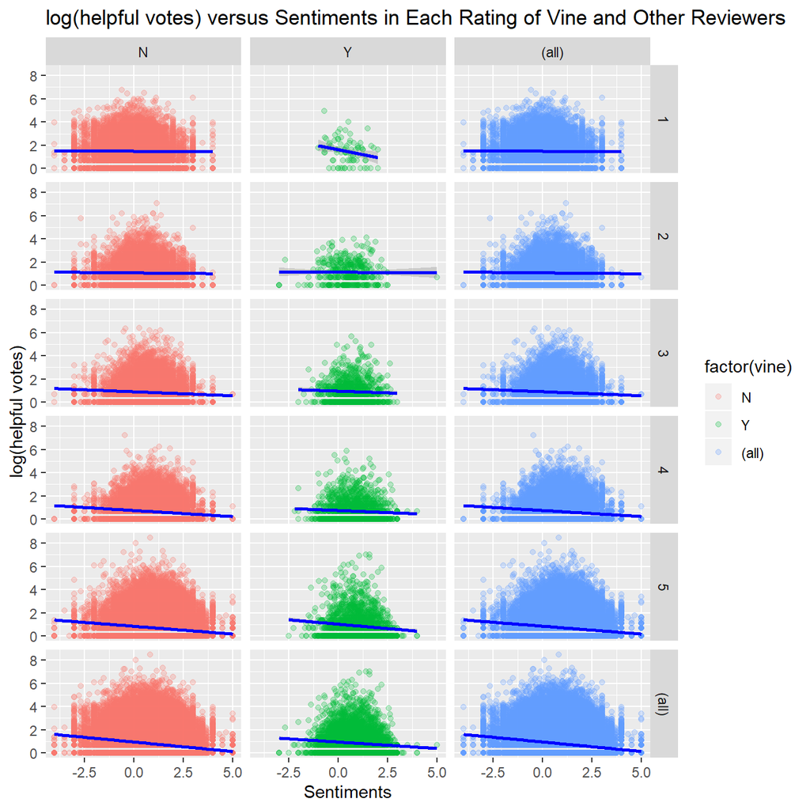

```r
ggplot(subset(Amazon_senti,helpful_votes>0), aes(x = sentiment, y = log(helpful_votes), color = factor(vine)))+
    geom_point(alpha = 0.25)+
    geom_smooth(method = "lm",colour="blue")+
    facet_grid(star_rating~vine, margins = TRUE)+
    labs(x = "Sentiments", y = "log(helpful votes)")+
    ggtitle("log(helpful votes) versus Sentiments in Each Rating of Vine and Other Reviewers")
```

Additionally, the reviewers of the Vine program do not receive more helpful votes in their reviews. Most of their reviews also receive few helpful votes. Additionally, the reviewers of the Vine program tend to write more netually, so they seldom produce reviews with very high or very low sentiments.

The plot also show that the reviewers of the Vine program wrote reviews more nuturally than the others giving the same star rating. This is reasonable beacuse they are responsible for writing good reviews, so they should not be too sentimental. They also tend to not give ratings of 1 or 2. One possible reason is that they are less likely to be given products of low ratings because the vendors of those products are less likely to submit the products to the program. Another possible reason is that reviewers of the Vine program are relatively neutral raters, since they are the representative reviewers. This fact implies that probably the Vine program works as Amazon expected, but maybe they should also test and review more products with low ratings.

## 3. Further exploration

#### hypothesis:

The reviewers who usually write long reviews are usually verified purchasers and tend to more helpful reviews.

#### Outline and pseudocode

1. Create additional variables Firstly I will create a variable in Amazon which is the character count of the review body and a variable of the proportion of helpful votes among all votes, and save as Amazon2.
2. Examine review lengths Secondly I will examine the distribution of review lengths, and get Q3.
3. Extract reviewers  
   Then I will extract the data of specific reviewers who have more than 5 reviews together with their mean review lengths and mean proportion of helpful votes.
4. Calculate results A subset of the chosen reviewers will be created to only contain reviewers with average review length larger than Q3 of review lengths. Another subset of the other reviews will also be created. Then, we will get the average of mean proportion of helpful votes of them and that of the others.
5. Compare results Finally I would test the null hypothesis that the average of mean proportion of helpful votes of these reviewers is equal to the average of mean proportion of helpful votes of the others.

#### Implementation of R code

Steps 1, 2:

```r
Amazon2 <- Amazon %>%
  mutate(length = nchar(review_body), proportion_helpful = helpful_votes/total_votes)
Amazon2 <- Amazon2[!is.na(Amazon2$proportion_helpful),]
summary(Amazon2$length)
```

```
##    Min. 1st Qu.  Median    Mean 3rd Qu.    Max.    NA's
##     1.0   133.0   284.0   670.1   697.0 48560.0       3
```

Therefore, the 3rd Quotile of review lengths is 697.0

Steps 3, 4:

```r
chosen_reviewers<-summarise(group_by(Amazon2,customer_id.x),count=n(),mean_l=mean(length),mean_p=mean(proportion_helpful)) %>% subset(count>=5)

others<-subset(chosen_reviewers, mean_l<697.0)
chosen_reviewers2<-subset(chosen_reviewers, mean_l>=697.0)

mean(chosen_reviewers2$mean_p)
```

```
## [1] 0.7917253
```

```r
mean(others$mean_p)
```

```
## [1] 0.6529778
```

The mean of the proportion is about 0.7917253. It is larger than the mean of helpful proportions of votes of other reviewers’ reviews, which is 0.6529778.

Step 5:

```r
t.test(chosen_reviewers$mean_p, others$mean_p)
```

```
##
##  Welch Two Sample t-test
##
## data:  chosen_reviewers$mean_p and others$mean_p
## t = 6.5654, df = 215.58, p-value = 3.814e-10
## alternative hypothesis: true difference in means is not equal to 0
## 95 percent confidence interval:
##  0.08338789 0.15493631
## sample estimates:
## mean of x mean of y
## 0.7721399 0.6529778
```